# R Exercises - Spectroscopic data

2023-01-25

# Exercise 1

- Load the `readxl` and `tidyverse` libraries.
- Load `FTIR_rocks.xlsx` into a `data.frame` (in fact, `tibble`).
- Rename the columns with simpler names, such as “w”, “r1”, “r2” and “r3”
- Find the wavenumber value of the maximum of each spectrum
- Create a function `norm01()` that, given a vector, returns the vector normalized to [0,1]
- Normalize all columns of FTIR intensity to [0,1]
- Using base graphics or `ggplot2`, as you wish, try to reproduce the following graphs:

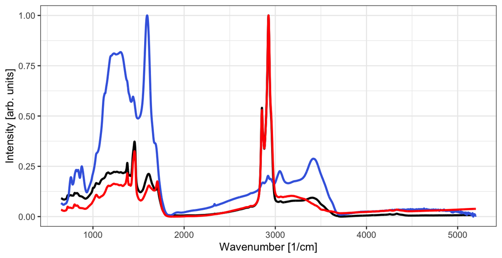

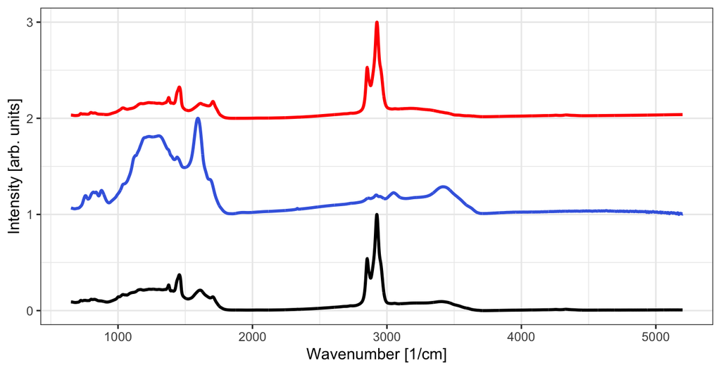

# Exercise 2

- Find in the folder “Data” the list of files with the pattern “rubis_” in their name (check out the `list.files()` function) and store it in `flist`
- What is the length of `flist`?
- Initialize two empty tibbles called `spec` (storing all spectra) and `maxpos` (storing the position of the maximum for each spectrum)
- Using a `for` loop, load each file in `flist` and store them into `spec` by *making it tidy*, and store the position of the maximum of each spectrum in `maxpos`
- Plot the first spectrum in `spec` to see the x range
- Using `ggplot2`, plot the spectra normalized to [0,1] and stacked on top of each other with a vertical shift of 1
- Plot the evolution of the position of the maximum (expected graph below)

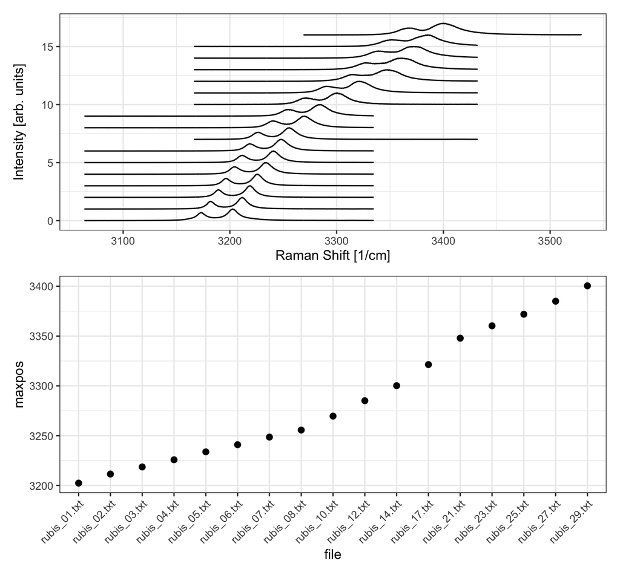